# A machine learning approach to evaluate exercise performance

jw149j

Tuesday, September 22, 2015

### Executive Summary.

A group of volunteers were trained to perform a series of supervised exercises with weights, involving a number of defined ‘mistakes’ in technique. Each performance was recorded using a series of accelerometers attached to a number of locations on the body, and a range of values recorded. The purpose of this analysis is to determine a machine learning model which can consistently determine the mode of exercise (i.e. which specific ‘mistake’ is being performed) from a novel set of accelerometer readings. The experiment is described in detail [here](http://groupware.les.inf.puc-rio.br/work.jsf?p1=11201). The analysis concluded that a random forest model produced a good predictive model, but required major system resources ( as indicated by time to complete the model building).

**Load the required packages for this analysis**

```r
library(digest)
library(caret)
library(randomForest)
library(kernlab)
set.seed(91295)
```

## Obtain and Load the Data

The correct data sets are required for this analysis:  
1) a set of data >19000 instances from https://d396qusza40orc.cloudfront.net/predmachlearn/pml-training.csv  
2) a set of test instances for *automatic* **evaluation of the model** [https://d396qusza40orc.cloudfront.net/predmachlearn/pml-testing.csv)](https://d396qusza40orc.cloudfront.net/predmachlearn/pml-testing.csv) (auto_TestSet).

```r
library(digest)
if(file.exists("pml-training.csv")&&(identical(digest("pml-training.csv",file=TRUE),"56926c78af383dcdc2060407942e52e9"))){
} else{  download.file("http://d396qusza40orc.cloudfront.net/predmachlearn/pml-training.csv","pml-training.csv")}

if(file.exists("pml-testing.csv")&&(identical(digest("pml-testing.csv",file=TRUE),"bc4174f3ec5dfcc5c570a1d2709272d9"))){
} else{  download.file("http://d396qusza40orc.cloudfront.net/predmachlearn/pml-testing.csv","pml-testing.csv") }
```

Manual inspection of the training data set indicates 3 distinct labels for data not available : **“NA”, “”** and **“#DIV/0!”** Read the data sets into data frames, using the above strings to indicate NA in the dataframe.

```r
baseData<-read.csv("pml-training.csv",na.strings=c("NA","#DIV/0!",""))
auto_TestSet<-read.csv("pml-testing.csv",na.strings=c("NA","#DIV/0!",""))
```

## Clean and Preprocess the Data Sets.

Determine the cleaning and pre-processing required of the data sets:

- Fields 1-7 are codes for participants and other data which can produce spurious overfitting  
  + remove from in the training data and test set
- determine all fields where >5% of entries are NA  
  + remove these columns from the training data and test set

Partition the coded training data into a working training set and a test set for final evaluation of the best performing method.

```r
# Determine and apply data cleaning criteria
numInst<-length(baseData[,1])
baseStrip_1<-baseData[,-(1:7)] ;
auto_testStrip_1<-auto_TestSet[,-(1:7)]
na_level<-colSums((is.na(baseStrip_1))/numInst)<0.05
trainData<-baseStrip_1[,na_level] ;
auto_testStrip_2<-auto_testStrip_1[,na_level]
# partition the coded data into a working training set and the final test set
trainSetindex <- createDataPartition(y = trainData[,ncol(trainData)], p = 0.70, list = FALSE)
trainSet<-trainData[trainSetindex,]
testSet<-trainData[-trainSetindex,]
```

There are 13737 instances in the training data and 5885 in the test set.

Preprocess the data set to optimize range, distribution etc.  
Remove the class identifiers from the data.

```r
ppc<-preProcess(trainSet[,-ncol(trainSet)],method=c("BoxCox","center","scale"))
ds<-predict(ppc,trainSet[,-ncol(trainSet)])
```

Perform PCA (Principal Component Analysis) and determine approx number of components required to optimize variance coverage (first 95% of variance).

```r
pca<-prcomp(ds)
cumSumms<-cumsum(100*pca$sdev^2)/sum(pca$sdev^2)
numComp<-sum(cumSumms<95)+1
```

As shown in the following figure, 26 components account for 95% of the variance:

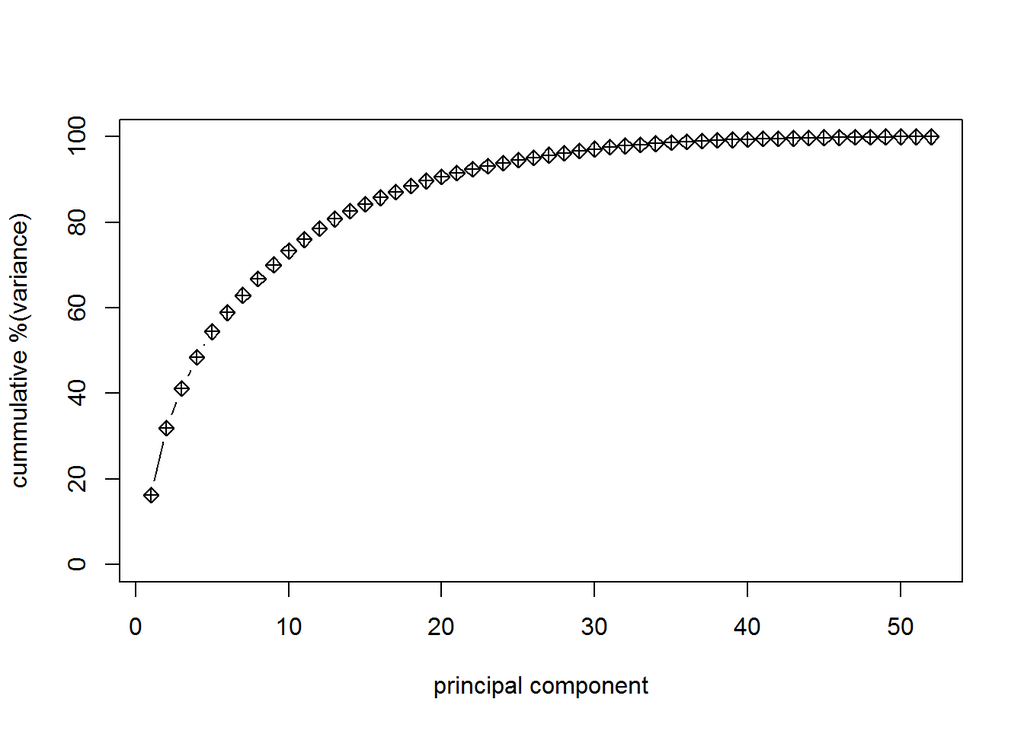

```r
plot((cumsum(100*pca$sdev^2)/sum(pca$sdev^2)), xlab="principal component",
ylab="cummulative %(variance)", type="b", pch=9,ylim=c(0,100))
```

**FIG1. Principal Component Analysis of data in the training data set.**

The classification codes were removed, along with the first 7 elements of each observation. The remaining variables were subjected to the BoxCox transformation to approximate normal distribuion, then centred and scaled. Robust imputation was ensured by removing all columns with more than 5% missing values. The cummulative variance accounted for by the components calculated by PCA are shown. 95% of variance is accounted for by the first 26 components.

Use the preprocess function to transform the training and test data

```r
ppc2<-preProcess(trainSet[,-ncol(trainSet)],method=c("BoxCox","center","scale","pca"),pcaComp=numComp)
reduced_trSet<-predict(ppc2,trainSet[,-ncol(trainSet)])
reduced_trSet[,ncol(reduced_trSet)+1]<-trainSet[,ncol(trainSet)]
reduced_testSet<-predict(ppc2,testSet[,-ncol(testSet)])
reduced_testSet[,ncol(reduced_testSet)+1]<-testSet[,ncol(testSet)]
auto_testPCA<-predict(ppc2,auto_testStrip_2[,-ncol(auto_testStrip_2)])
```

## Test the performance of a set of machine learning algorithms applied to the test datset.

### Benchmark

The benchmark level of discrimination is determined by randomising the vector of class values for the training set: maintaining the proportions of the classes but effectively randomly selecting them.

```r
   class<-reduced_trSet[,ncol(reduced_trSet)]
   random<-sample(class)
   matx<-confusionMatrix(random,class)
   v<-paste(capture.output(matx),collapse="\n")
   cat(v)
```

```
## Confusion Matrix and Statistics
##
##           Reference
## Prediction    A    B    C    D    E
##          A 1112  747  704  613  730
##          B  729  540  486  428  475
##          C  721  444  409  387  435
##          D  638  429  365  389  431
##          E  706  498  432  435  454
##
## Overall Statistics
##
##                Accuracy : 0.2114
##                  95% CI : (0.2046, 0.2183)
##     No Information Rate : 0.2843
##     P-Value [Acc > NIR] : 1.0000
##
##                   Kappa : 0.0026
##  Mcnemar's Test P-Value : 0.9255
##
## Statistics by Class:
##
##                      Class: A Class: B Class: C Class: D Class: E
## Sensitivity           0.28469  0.20316  0.17070  0.17274  0.17980
## Specificity           0.71580  0.80883  0.82479  0.83779  0.81529
## Pos Pred Value        0.28469  0.20316  0.17070  0.17274  0.17980
## Neg Pred Value        0.71580  0.80883  0.82479  0.83779  0.81529
## Prevalence            0.28434  0.19349  0.17442  0.16394  0.18381
## Detection Rate        0.08095  0.03931  0.02977  0.02832  0.03305
## Detection Prevalence  0.28434  0.19349  0.17442  0.16394  0.18381
## Balanced Accuracy     0.50024  0.50599  0.49775  0.50526  0.49754
```

This demonstates an overall accuaracy of **0.211** with an average ‘by class’ balanced accuracy of **0.501**.

## Test a panel of machine learning algorithms

Define a function to automate the running and comparisons of a range of machine learning methods, utilising the **train()** method of the **caret** package. The algorithms are assessed in terms of the overall and ‘by class’ balanced accuracy, and by the time required to complete the algorithm.

```r
runTrain<-function(data,method,seed=6543){
   library(caret)
   set.seed(seed)
# shuffle the data by row
   data <- data[sample(nrow(data)),]
# extract a temporary training and test set
   trainSetindex <- createDataPartition(y = data[,ncol(data)], p = 0.75, list = FALSE)
   trainSet<-data[trainSetindex,]
   redTrSet<-trainSet[,-ncol(trainSet)]
   TrKey<-trainSet[,ncol(trainSet)]
   tSet<-data[-trainSetindex,]
   redTeSet<-tSet[,-ncol(tSet)]
   TeKey<-tSet[,ncol(tSet)]
# create file name for model
   file = paste(method,".mdl",sep="")
# train the model
   trainedModel<-train(redTrSet,TrKey,method=method)
   save(trainedModel,file=file)
# predict from the test set
   predicted<-predict(trainedModel,newdata=redTeSet)
# confusion matrix:
   matx<-confusionMatrix(predicted,TeKey)
# save the confusion Matrix
   save(matx,file=paste(method,".cfm",sep=""))
# save the confusion Matrix
save(matx,file=paste(method,".cfm",sep=""))
# construct a return string
returnTxt<-paste("\n====================================================\n","model =",file,"length of processing =",sprintf("%.1f",trainedModel$times$everything["elapsed"])," seconds\n",sep=" ")
returnTxt<-paste(returnTxt,"","PERFORMANCE","===========","",sep="\n")
returnTxt<-paste(returnTxt,"Overall accuracy\n",round(matx$overall['Accuracy'],3),"\n","By Class Balanced Accuracy","\n",sep="")
cat(returnTxt)
cat(paste(names(matx$byClass[,8]),sep="\t")); cat("\n")
cat(paste(round(matx$byClass[,8],3),sep="\t    \t")); cat("\n")
}
```

```r
methods<-c("rpart","lda","svmRadial","rf")
best<-0;
meth<-""
seeds<-c(1496,1776,1812,1969)
for(i in seq_along(methods)){
    summy<-runTrain(reduced_trSet,methods[i],seed=seeds[i])
    load(paste(methods[i],".cfm",sep=""))
    if(matx$overall['Accuracy']>best){

       best<-matx$overall['Accuracy']
       meth<-methods[i]
    }
    summy
}
```

```
##
## ====================================================
##  model = rpart.mdl length of processing = 90.4  seconds
##
##
## PERFORMANCE
## ===========
## Overall accuracy
## 0.398
## By Class Balanced Accuracy
## Class: A Class: B Class: C Class: D Class: E
## 0.639 0.562 0.5 0.616 0.63
```

```
##
## ====================================================
##  model = lda.mdl length of processing = 8.4  seconds
##
##
## PERFORMANCE
## ===========
## Overall accuracy
## 0.531
## By Class Balanced Accuracy
## Class: A Class: B Class: C Class: D Class: E
## 0.727 0.64 0.679 0.748 0.716
##
## ====================================================
##  model = svmRadial.mdl length of processing = 4731.9  seconds
##
##
## PERFORMANCE
## ===========
## Overall accuracy
## 0.89
## By Class Balanced Accuracy
## Class: A Class: B Class: C Class: D Class: E
## 0.97 0.909 0.905 0.917 0.933
##
## ====================================================
##  model = rf.mdl length of processing = 4009.3  seconds
##
##
## PERFORMANCE
## ===========
## Overall accuracy
## 0.966
## By Class Balanced Accuracy
## Class: A Class: B Class: C Class: D Class: E
## 0.992 0.973 0.967 0.967 0.986
```

```r
outtext<-paste("The best method tried is ",meth," with an accuracy of ",round(best,3),".\n")
cat(outtext)
```

```
## The best method tried is  rf  with an accuracy of  0.966 .
```

## Out of sample performance of the rf method

The best scoring method ( rf ) is applied to the test data. From this determine the *out of sample error* for the model.

```r
bestMdlFile = paste(meth,".mdl",sep="")
load(bestMdlFile)

oof<-reduced_testSet[,-ncol(reduced_testSet)]
predicted<-predict(trainedModel,newdata=oof)
testKeys<-testSet[,ncol(testSet)]
falsecalls<-sum(predicted != testKeys)
matx<-confusionMatrix(predicted,testKeys)

v<-paste(capture.output(matx),collapse="\n")

cat(v)
```

```
## Confusion Matrix and Statistics
##
##           Reference
## Prediction    A    B    C    D    E
##          A 1652   23    2    0    1
##          B   13 1085   25    0    9
##          C    4   27  977   49    9
##          D    1    3   20  913   15
##          E    4    1    2    2 1048
##
## Overall Statistics
##
##                Accuracy : 0.9643
##                  95% CI : (0.9593, 0.9689)
##     No Information Rate : 0.2845
##     P-Value [Acc > NIR] : < 2.2e-16
##
##                   Kappa : 0.9549
##  Mcnemar's Test P-Value : 6.616e-06
##
## Statistics by Class:
##
##                      Class: A Class: B Class: C Class: D Class: E
## Sensitivity            0.9869   0.9526   0.9522   0.9471   0.9686
## Specificity            0.9938   0.9901   0.9817   0.9921   0.9981
## Pos Pred Value         0.9845   0.9585   0.9165   0.9590   0.9915
## Neg Pred Value         0.9948   0.9886   0.9898   0.9897   0.9930
## Prevalence             0.2845   0.1935   0.1743   0.1638   0.1839
## Detection Rate         0.2807   0.1844   0.1660   0.1551   0.1781
## Detection Prevalence   0.2851   0.1924   0.1811   0.1618   0.1796
## Balanced Accuracy      0.9903   0.9713   0.9670   0.9696   0.9834
```

The out of sample error determined for this model (1 - accuracy, where accuracy reflects the performance of the model applied to the test set ) is **0.036** .

Application of this model to the auto_test data set gives the following prediction:

```r
predicted<-predict(trainedModel,newdata=auto_testPCA)
predicted
```

```
##  [1] B A B A A E D B A A B C B A E E A B B B
## Levels: A B C D E
```